# Get CRediT

Joseph V. Casillas

Last upate: 2022-11-19

## Load libraries

```r
library("googlesheets4")
library("googledrive")
library("xml2")
library("dplyr")
library("tidyr")
library("glue")
library("stringr")
library("ggplot2")
library("ggtext")
library("forcats")
library("readr")
library("kableExtra")
library("countrycode")
```

## Get google sheet and tidy

```r
# give gargle permission
drive_auth(email = TRUE)

# Locate file, check ID
drive_find(n_max = 5, type = "spreadsheet")

# Old sheet
#all_data_temp <- read_sheet("1lXmubF42sTCoOaECXGzo20GCFxX51MWFOKhX8euNtuA") %>%
#  janitor::clean_names()

# New sheet
all_data_temp <- read_sheet("1lXmubF42sTCoOaECXGzo20GCFxX51MWFOKhX8euNtuA") %>%
  janitor::clean_names()

# Download to doc folder
write_csv(all_data_temp, "data/CRediT/MSA_tenzing_contribution.csv")
```

```r
# Load data
#all_data_temp <- read_csv("data/CRediT/MSA_tenzing_contribution.csv")
all_data_temp <-
  read_csv("data/CRediT/MSA_tenzing_contribution-corrected_contributions.csv") %>%
  janitor::clean_names() %>%
  mutate(
    primary_affiliation_country = if_else(
      primary_affiliation_country == "Aotearoa",
      "New Zealand",
      .$primary_affiliation_country
      ),
    cntry = countrycode(
      primary_affiliation_country,
      origin = 'country.name',
      destination = 'iso3c'
      ),
    flag = countrycode(
      cntry,
      origin = 'iso3c',
      destination = 'unicode.symbol')
    )

# Create vector of surnames of initiating authors
initiating_authors <- c("Coretta", "Casillas", "Roettger")
extras <- c("Roessig", "Franke")

# Subset initiating authors
initiators <- all_data_temp %>%
  filter(surname %in% initiating_authors) %>%
  mutate(is_initiating = 1)

# Subset initiating authors
others <- all_data_temp %>%
  filter(surname %in% extras) %>%
  mutate(is_initiating = 1.5)

# Subset analysts
analysts <- all_data_temp %>%
  filter(!(surname %in% c(initiating_authors, extras))) %>%
  mutate(is_initiating = 0) %>%
  arrange(surname)

# Combine dfs in correct order
contributors <- bind_rows(initiators, others, analysts) %>%
  mutate(middle_name = replace_na(middle_name, ""),
    initials = glue::glue("{str_sub(firstname, 1, 1)}{str_sub(middle_name, 1, 1)}{str_sub(surname, 1, 1)}")) %>%
  unite(name, c("firstname", "middle_name", "surname"), sep = " ", remove = F) %>%
  mutate(name = str_replace_all(name, "  ", " ")) %>%
  bind_rows(
    slice(., which(name != "Timo B. Roettger")),
    slice(., which(name == "Timo B. Roettger"))
    ) %>%
  tail(nrow(.) / 2)
```

## Author list

```r
author_list <- contributors %>%
  pull(name) %>%
  knitr::combine_words(words = .)
```

These are the authors:  
Stefano Coretta, Joseph V. Casillas, Simon Roessig, Michael Franke, Byron Ahn, Ali H. Al-Hoorie, Jalal Al-Tamimi, Najd E. Alotaibi, Mohammed K. AlShakhori, Ruth M. Altmiller, Pablo Arantes, Angeliki Athanasopoulou, Melissa M. Baese-Berk, George Bailey, Cheman Baira A Sangma, Eleonora J. Beier, Gabriela M. Benavides, Nicole Benker, Emelia P. BensonMeyer, Nina R. Benway, Grant M. Berry, Liwen Bing, Christina Bjorndahl, Mariska Bolyanatz, Aaron Braver, Violet A. Brown, Alicia M. Brown, Alejna Brugos, Erin M. Buchanan, Tanna Butlin, Andrés Buxó-Lugo, Coline Caillol, Francesco Cangemi, Christopher Carignan, Sita Carraturo, Tiphaine Caudrelier, Eleanor Chodroff, Michelle Cohn, Johanna Cronenberg, Olivier Crouzet, Erica L. Dagar, Charlotte Dawson, Carissa A. Diantoro, Marie Dokovova, Shiloh Drake, Fengting Du, Margaux Dubuis, Florent Duême, Matthew Durward, Ander Egurtzegi, Mahmoud M. Elsherif, Janina Esser, Emmanuel Ferragne, Fernanda Ferreira, Lauren K. Fink, Sara Finley, Kurtis Foster, Paul Foulkes, Rosa Franzke, Gabriel Frazer-McKee, Robert Fromont, Christina García, Jason Geller, Camille L. Grasso, Pia Greca, Martine Grice, Magdalena S. Grose-Hodge, Amelia J. Gully, Caitlin Halfacre, Ivy Hauser, Jen Hay, Robert Haywood, Sam Hellmuth, Allison I. Hilger, Nicole Holliday, Damar Hoogland, Yaqian Huang, Vincent Hughes, Ane Icardo Isasa, Zlatomira G. Ilchovska, Hae-Sung Jeon, Jacq Jones, Mágat N. Junges, Stephanie Kaefer, Constantijn Kaland, Matthew C. Kelley, Niamh E. Kelly, Thomas Kettig, Ghada Khattab, Ruud Koolen, Emiel Krahmer, Dorota Krajewska, Andreas Krug, Abhilasha A. Kumar, Anna Lander, Tomas O. Lentz, Wanyin Li, Yanyu Li, Maria Lialiou, Ronaldo M. Lima Jr., Justin J. H. Lo, Julio Cesar Lopez Otero, Bradley Mackay, Bethany MacLeod, Mel Mallard, Carol-Ann Mary McConnellogue, George Moroz, Mridhula Murali, Ladislas Nalborczyk, Filip Nenadić, Jessica Nieder, Dušan Nikolić, Francisco G. S. Nogueira, Heather M. Offerman, Elisa Passoni, Maud Pélissier, Scott J. Perry, Alexandra M. Pfiffner, Michael Proctor, Ryan Rhodes, Nicole Rodríguez, Elizabeth Roepke, Jan P. Röer, Lucia Sbacco, Rebecca Scarborough, Felix Schaeffler, Erik Schleef, Dominic Schmitz, Alexander Shiryaev, Márton Sóskuthy, Malin Spaniol, Joseph A. Stanley, Alyssa Strickler, Alessandro Tavano, Fabian Tomaschek, Benjamin V. Tucker, Rory Turnbull, Kingsley O. Ugwuanyi, Iñigo Urrestarazu-Porta, Ruben van de Vijver, Kristin J. Van Engen, Emiel van Miltenburg, Bruce Wang, Natasha Warner, Simon Wehrle, Hans Westerbeek, Seth Wiener, Stephen Winters, Sidney G.-J. Wong, Anna Wood, Jane Wottawa, Chenzi Xu, Germán Zárate-Sández, Georgia Zellou, Cong Zhang, Jian Zhu, and Timo B. Roettger

## Institutions

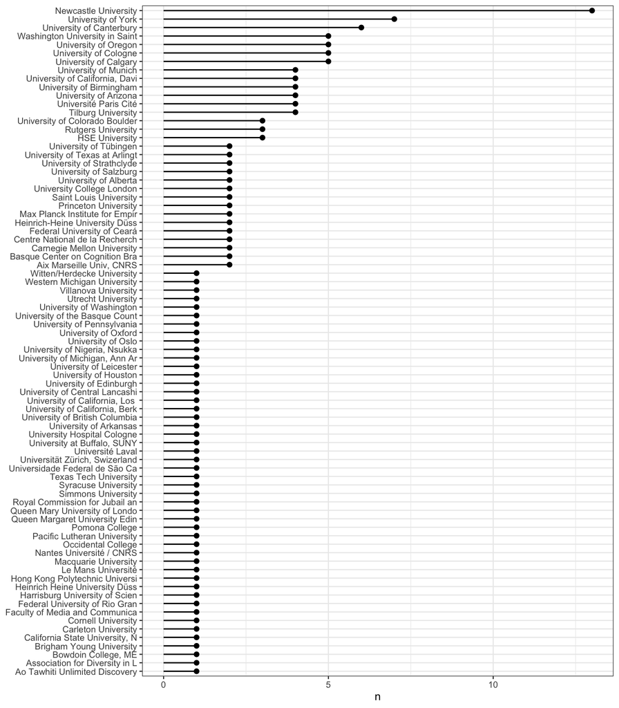

```r
# Get count of unique affiliations
affiliations <- contributors %>%
  count(primary_affiliation_university) %>%
  arrange(n)

n_no_affiliation <- sum(is.na(contributors$primary_affiliation_university))

# Plot affiliations as a function of n
affiliations %>%
  mutate(lab_truc = str_sub(primary_affiliation_university, 1, 30),
    lab_truc = fct_reorder(lab_truc, n, min)) %>%
  ggplot() +
  aes(x = n, y = lab_truc) +
  geom_segment(aes(x = 0, xend = n, yend = lab_truc)) +
  geom_point() +
  labs(y = NULL) +
  theme_bw(base_size = 9)
```

There were 157 contributors from 79 institutions. Zero analysts did not include their primary affiliation.

## Countries

[figure not shown]

```r
open <- "<img src="
close <- " width='25' /><br>"

n_countries <- contributors %>%
  count(primary_affiliation_country, flag) %>%
  arrange(n) %>%
  mutate(
    country = primary_affiliation_country,
    labs = case_when(
      country == "Australia" ~
        glue("{open}'https://img.icons8.com/emoji/512/australia-emoji.png'{close}"),
      country == "Hong Kong SAR, China" ~
        glue("{open}'https://emojipedia-us.s3.dualstack.us-west-1.amazonaws.com/thumbs/120/apple/325/flag-hong-kong-sar-china_1f1ed-1f1f0.png'{close}"),
      country == "Nigeria" ~
        glue("{open}'https://img.icons8.com/emoji/512/nigeria-emoji.png'{close}"),
      country == "Norway" ~
        glue("{open}'https://img.icons8.com/emoji/512/norway-emoji.png'{close}"),
      country == "Saudi Arabia" ~
        glue("{open}'https://img.icons8.com/emoji/512/saudi-arabia-emoji.png'{close}"),
      country == "Serbia" ~
        glue("{open}'https://img.icons8.com/emoji/512/serbia-emoji.png'{close}"),
      country == "Switzerland" ~
        glue("{open}'https://img.icons8.com/emoji/512/switzerland-emoji.png'{close}"),
      country == "Austria" ~
        glue("{open}'https://img.icons8.com/emoji/512/austria-emoji.png'{close}"),
      country == "Russia" ~
        glue("{open}'https://img.icons8.com/emoji/512/russia-emoji.png'{close}"),
      country == "Spain" ~
        glue("{open}'https://img.icons8.com/emoji/512/spain-emoji.png'{close}"),
      country == "Brazil" ~
        glue("{open}'https://img.icons8.com/emoji/512/brazil-emoji.png'{close}"),
      country == "Netherlands" ~
        glue("{open}'https://img.icons8.com/emoji/512/netherlands-emoji.png'{close}"),
      country == "New Zealand" ~
        glue("{open}'https://img.icons8.com/emoji/512/new-zealand-emoji.png'{close}"),
      country == "Canada" ~
        glue("{open}'https://img.icons8.com/emoji/512/canada-emoji.png'{close}"),
      country == "France" ~
        glue("{open}'https://img.icons8.com/emoji/512/france-emoji.png'{close}"),
      country == "Germany" ~
        glue("{open}'https://img.icons8.com/emoji/512/germany-emoji.png'{close}"),
      country == "United Kingdom" ~
        glue("{open}'https://img.icons8.com/emoji/512/united-kingdom-emoji.png'{close}"),
      country == "United States" ~
        glue("{open}'https://img.icons8.com/emoji/512/united-states-emoji.png'{close}")
    ),
    country = fct_reorder(country, n, max))

n_countries %>%
  ggplot() +
  aes(x = n, y = country) +
  geom_segment(aes(x = 0, xend = n, yend = country), size = 2,
    color = "grey25", lineend = "round") +
  geom_point(size = 6) +
  geom_text(aes(label = n), color = "white", size = 3) +
  labs(x = "n", y = NULL,
    title = "Number of analysts by country",
    subtitle = glue("(n = {sum(n_countries$n)})")) +
  theme_bw(base_size = 13, base_family = "Times") +
  scale_y_discrete(name = NULL, labels = n_countries$labs) +
  theme(axis.text.y = element_markdown(color = "black", vjust = 0.65),
    panel.grid.major = element_line(colour = 'grey90', size = 0.15),
    panel.grid.minor = element_line(colour = 'grey90', size = 0.15))
```

```r
n_countries %>%
  arrange(desc(n)) %>%
  transmute(Country = glue("{flag} {country}"), n) %>%
  knitr::kable(format = "pandoc")
```

| Country | n |
| --- | --- |
| 🇺🇸 United States | 53 |
| 🇬🇧 United Kingdom | 34 |
| 🇩🇪 Germany | 19 |
| 🇨🇦 Canada | 10 |
| 🇫🇷 France | 10 |
| 🇳🇿 New Zealand | 7 |
| 🇳🇱 Netherlands | 5 |
| 🇧🇷 Brazil | 4 |
| 🇷🇺 Russia | 3 |
| 🇪🇸 Spain | 3 |
| 🇦🇹 Austria | 2 |
| 🇦🇺 Australia | 1 |
| 🇭🇰 Hong Kong SAR, China | 1 |
| 🇳🇬 Nigeria | 1 |
| 🇳🇴 Norway | 1 |
| 🇸🇦 Saudi Arabia | 1 |
| 🇷🇸 Serbia | 1 |
| 🇨🇭 Switzerland | 1 |

## Contributor roles taxonomy

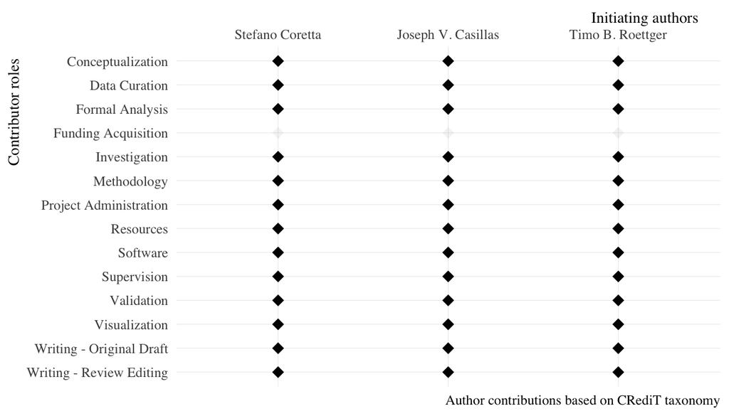

```r
# Vector of formated contributor roles
contributor_role <- c(
    "Conceptualization", "Data curation", "Formal Analysis",
    "Funding acquisition", "Investigation", "Methodology",
    "Project administration", "Resources", "Software", "Supervision",
    "Validation", "Visualization", "Writing - original draft",
    "Writing - review & editing"
  )

# Format contributors for plotting
cr_prep <- contributors %>%
  select(name, surname, conceptualization:writing_review_editing,
         is_initiating, initials) %>%
  pivot_longer(
    cols = -c("name", "surname", "is_initiating", "initials"),
    names_to = "contributor_roles",
    values_to = "val"
    ) %>%
  mutate(val = as.numeric(val)) %>%
  group_by(name, contributor_roles) %>%
  mutate(order_x = seq_along(name)) %>%
  group_by(name) %>%
  mutate(order_y = seq_along(name)) %>%
  ungroup() %>%
  mutate(contributor_roles = fct_rev(contributor_roles))


# Plot initiating authors
cr_prep %>%
  filter(is_initiating == 1) %>%
  mutate(name = fct_relevel(name, "Stefano Coretta", "Joseph V. Casillas"),
    contributor_roles = str_replace_all(contributor_roles, "_", " "),
    contributor_roles = str_replace_all(contributor_roles, "ting ", "ting - "),
    contributor_roles = str_to_title(contributor_roles)
    ) %>%
  ggplot() +
  aes(x = name, y = contributor_roles, alpha = val) +
    geom_point(size = 3.5, pch = 18, show.legend = F) +
    scale_x_discrete(position = "top") +
    scale_y_discrete(limits = rev) +
    scale_alpha_continuous(range = c(0.05, 1)) +
    labs(x = "Initiating authors", y = "Contributor roles",
         caption = "Author contributions based on CRediT taxonomy") +
    theme_minimal(base_size = 12, base_family = "Times") +
    theme(
      axis.title.y = element_text(size = rel(.9), hjust = 0.95),
      axis.title.x = element_text(size = rel(.9), hjust = 0.95),
      panel.grid.major = element_line(colour = 'grey90', size = 0.15),
      panel.grid.minor = element_line(colour = 'grey90', size = 0.15)
    )
```

```r
ggsave("figs/credit-taxonomy-initiators.png", width = 7, height = 5)
```

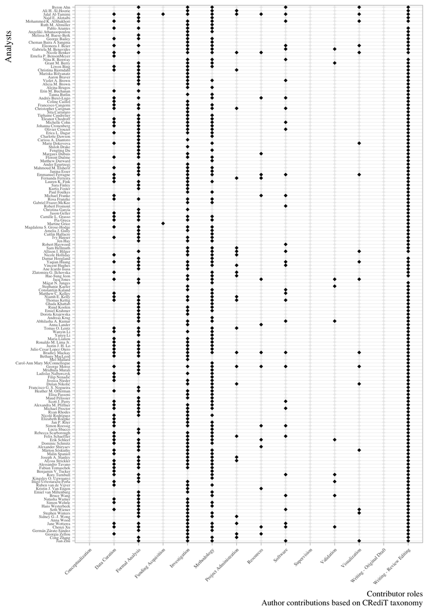

```r
cr_prep %>%
  filter(is_initiating != 1) %>%
  arrange(surname) %>%
  group_by(contributor_roles) %>%
  mutate(order = seq_along(name),
    name = fct_reorder(name, order),
    contributor_roles = str_replace_all(contributor_roles, "_", " "),
    contributor_roles = str_replace_all(contributor_roles, "ting ", "ting - "),
    contributor_roles = str_to_title(contributor_roles)
    ) %>%
  ggplot() +
  aes(y = name, x = contributor_roles, alpha = val) +
    geom_point(size = 1.75, pch = 18, show.legend = F) +
    scale_alpha_continuous(range = c(0.05, 1)) +
    scale_y_discrete(limits = rev) +
    labs(x = NULL, y = "Analysts",
         caption = "Contributor roles\nAuthor contributions based on CRediT taxonomy") +
    theme_light(base_size = 12, base_family = "Times") +
    theme(
      axis.title.y = element_text(size = rel(.9), hjust = 0.95),
      axis.title.x = element_text(size = rel(.9), hjust = 0.95),
      panel.grid.major = element_line(colour = 'grey90', size = 0.15),
      panel.grid.minor = element_line(colour = 'grey90', size = 0.15),
      axis.text.x = element_text(angle = 45, hjust = 1, vjust = 1,
                                     size = rel(0.6)),
      axis.text.y = element_text(size = rel(0.5))
    )
```

```r
ggsave("figs/credit-taxonomy-analysts.png", width = 14, height = 10)
```

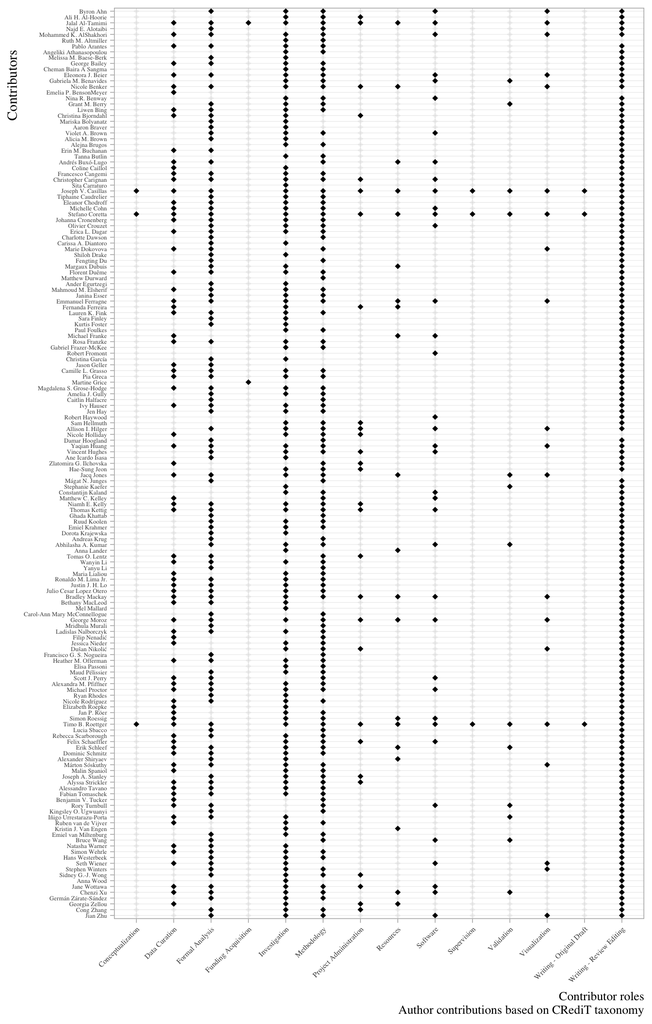

```r
cr_prep %>%
  arrange(surname) %>%
  group_by(contributor_roles) %>%
  mutate(order = seq_along(name),
    name = fct_reorder(name, order),
    contributor_roles = str_replace_all(contributor_roles, "_", " "),
    contributor_roles = str_replace_all(contributor_roles, "ting ", "ting - "),
    contributor_roles = str_to_title(contributor_roles)
    ) %>%
  ggplot() +
  aes(y = name, x = contributor_roles, alpha = val) +
    geom_point(size = 1.75, pch = 18, show.legend = F) +
    scale_y_discrete(limits = rev) +
    scale_alpha_continuous(range = c(0.05, 1)) +
    labs(x = NULL, y = "Contributors",
         caption = "Contributor roles\nAuthor contributions based on CRediT taxonomy") +
    theme_light(base_size = 12, base_family = "Times") +
    theme(
      axis.title.y = element_text(size = rel(.9), hjust = 0.95),
      axis.title.x = element_text(size = rel(.9), hjust = 0.95),
      panel.grid.major = element_line(colour = 'grey90', size = 0.15),
      panel.grid.minor = element_line(colour = 'grey90', size = 0.15),
      axis.text.x = element_text(angle = 45, hjust = 1, vjust = 1,
        size = rel(0.6)),
      axis.text.y = element_text(size = rel(0.5))
    )
```

```r
ggsave("figs/credit-taxonomy-all.png", width = 14, height = 10)
```

```r
# Copy author list to the clipboard so it can be pasted in RR
contributors %>%
  select(name) %>%
  mutate(name = glue::glue("- name: {name}\n")) %>%
  pull() %>%
  clipr::write_clip()


contributors %>%
  select(name,
         primary_affiliation_department,
         primary_affiliation_university,
         primary_affiliation_country) %>%
  transmute(
    name,
    name_man = glue::glue("- name: {name}"),
    num_man = glue::glue("- num: {1:nrow(.) + 1}")
  ) %>%
  pivot_longer(cols = -name, names_to = "col", values_to = "print") %>%
  pull(print) %>%
  clipr::write_clip()


contributors %>%
  select(name,
         primary_affiliation_department,
         primary_affiliation_university,
         primary_affiliation_country) %>%
  transmute(
    name,
    num_man = glue::glue("- num: {1:nrow(.) + 1}"),
    print = glue::glue("- org: {primary_affiliation_department}, {primary_affiliation_university}, {primary_affiliation_country}"),
  ) %>%
  pivot_longer(cols = -name, names_to = "col", values_to = "print") %>%
  pull(print) %>%
  clipr::write_clip()
```